# Exponential distribution in R vs the Central Limit Theorem

Ulrich van Staden

18/06/2021

## Overview

This report demonstrates the differences and similarities between theoretical and simulated results of an exponential distribution. The results to be compared are the mean, variance and standard deviation. First the exponential distribution was generated through using a 1000 random exponential values. Then the mean distribution were generated through the use of averages of 40 random exponentials generated, of which shows that the distribution tends to approximate a normal distribution.

## Simulations

The following theoretical parameters were given:

- **Rate** = lambda = 0.2
- **Mean** = 1/lambda = 5
- **Number of simulation** = 1000
- **Number of exponentials** = 40

The parameters listed above were used to plot 2 graphs: an **Exponential distribution** with a 1000 exponentials and a **Mean distribution** generated through a 1000 simulations of averages from 40 exponential distributions. These simulations have been simulated in R programming.

### Exponential Distribution

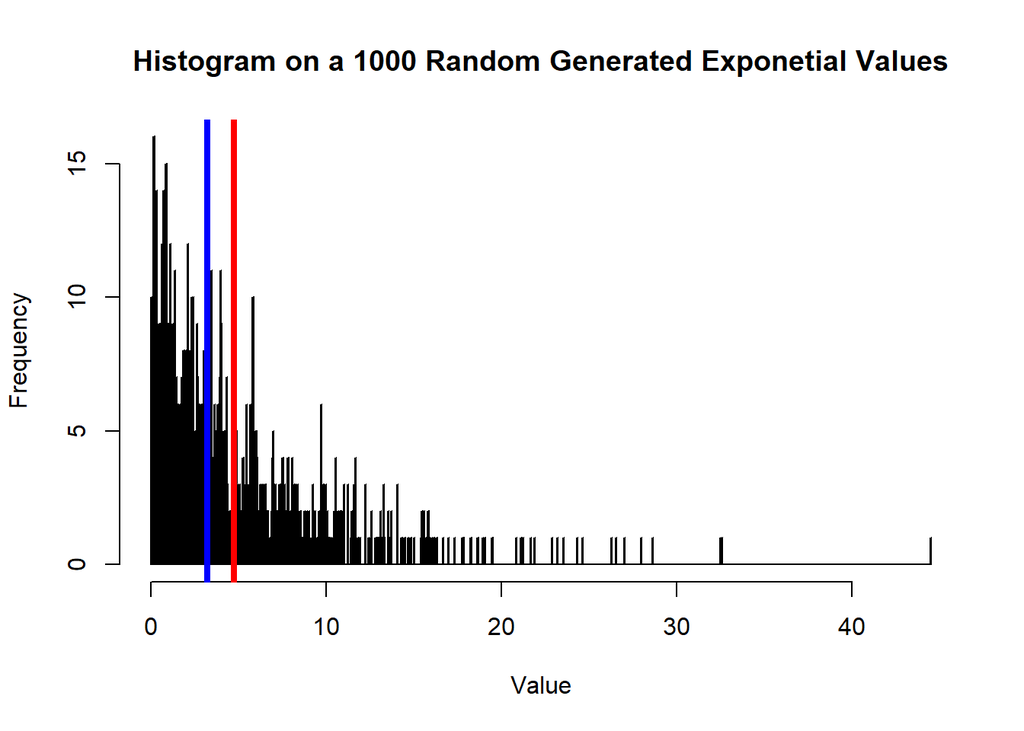

```r
n<-1000 #Number of observations
lambda <- 0.2 # Rate parameter
Expo1000 = rexp(n,lambda)
medianExp = median(Expo1000)
meanExp = mean(Expo1000)
hist(Expo1000
     ,main="Histogram on a 1000 Random Generated Exponetial Values"
     ,xlab="Value"
     ,breaks=1000)
abline(v = medianExp, col = "blue", lwd = 4)
abline(v = meanExp, col = "red", lwd = 4,)
```

### Mean Distribution

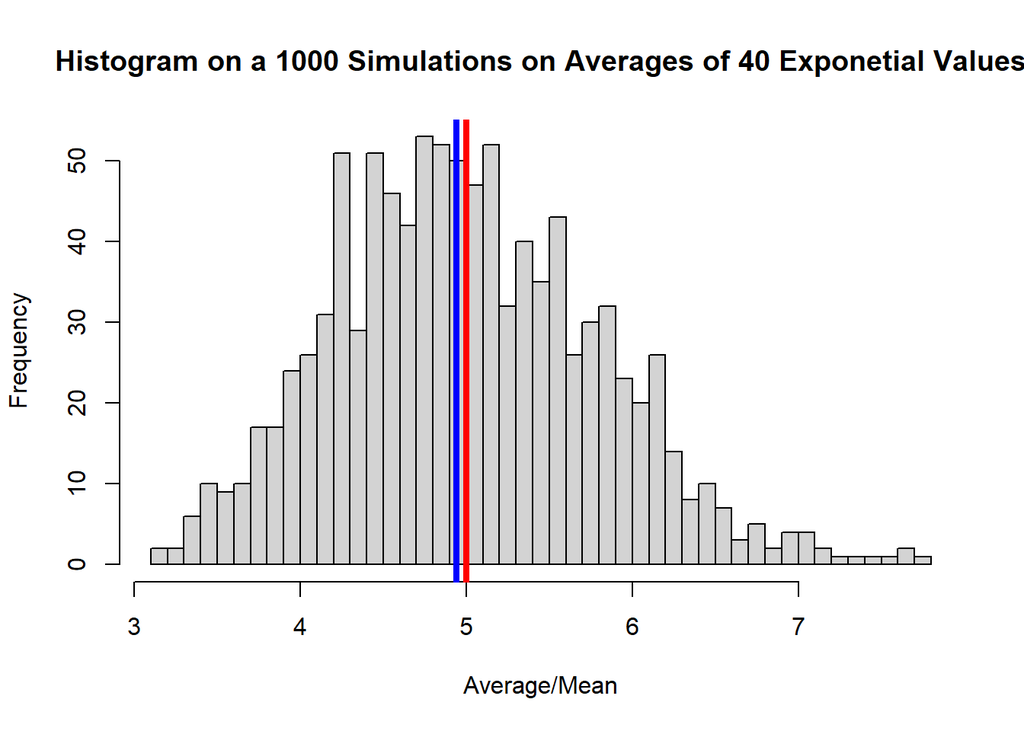

```r
n<-40 #Number of observations
lambda <- 0.2 # Rate parameter
Expo1000 = NULL

# Generates a 1000 random averages from 40 random generated exponential values.
for (i in 1 : 1000) Expo1000 = c(Expo1000, mean(rexp(n,lambda)))
medianExp = median(Expo1000)
meanExp = mean(Expo1000)
hist(Expo1000
     ,main="Histogram on a 1000 Simulations on Averages of 40 Exponetial Values"
     ,xlab="Average/Mean"
     ,breaks=40)
abline(v = medianExp, col = "blue", lwd = 4)
abline(v = meanExp, col = "red", lwd = 4,)
```

The graph above demonstrates the mean frequency of the random exponential values generated. The red line represents the mean = 4.9995209 and the blue line represents the median = 4.9389668. As you can see the median and the mean of this distribution are quite close and this is due to the average taken of from every 40 exponential values generated.

## Sample Mean versus Theoretical Mean

```r
# Sample mean of the simulation
SampleMean = mean(Expo1000)
#Theoretical Mean of the simulation
TheoreticalMean = 1/lambda
#Confidence Interval of the simulation, base on 95% confidence
ConfidenceInterval = t.test(Expo1000)$conf.int
```

| Parameters | Simulation | Theoretical | Confidence Interval |
| --- | --- | --- | --- |
| Mean | 4.9995209 | 5 | 4.9501198, 5.0489221 |

The mean is quite similar between the theoretical mean and the simulated mean and the theoretical mean is contained within the confidence interval.

## Sample Variance versus Theoretical Variance

```r
# Sample Standard Deviation of the simulation
SampleStadard = sd(Expo1000)
#Theoretical Standard Deviation of the simulation
TheoreticalStandard = (1/lambda)/sqrt(n)
# Sample Variance of the simulation
SampleVar = var(Expo1000)
#Theoretical Variance of the simulation
TheoreticalVar = (1/lambda)^2/n
```

| Parameters | Simulation | Theoretical |
| --- | --- | --- |
| Standard Deviation | 0.7960902 | 0.7905694 |
| Variance | 0.6337597 | 0.625 |

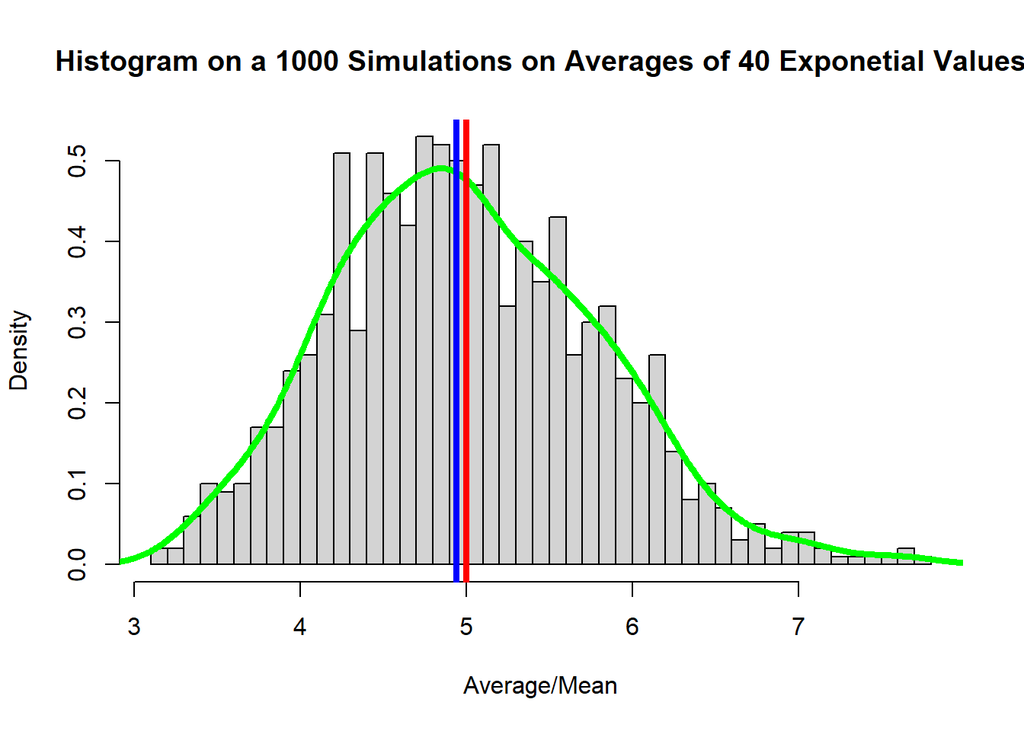

```r
hist(Expo1000
     ,main="Histogram on a 1000 Simulations on Averages of 40 Exponetial Values"
     ,xlab="Average/Mean"
     ,prob=TRUE
     ,breaks = 40)
lines(density(Expo1000), col = "green", lwd = 4)
abline(v = medianExp, col = "blue", lwd = 4)
abline(v = meanExp, col = "red", lwd = 4,)
```